# Pronóstico de la Inflación en Bolivia

David Ayala Muñoz

2025-02-11

# 1 Introducción

En este documento se realiza el pronóstico de la inflación para Bolivia para el año 2025, aplicando la metodología de Box-Jenkins (1976), para identificar un modelo autorregresivo integrado de media móvil ARIMA(p,d,q).

La Metodología de Box-Jenkins, consiste en:

1. Identificación: Consiste en identificar los valores (p,d,q), mediante los gráficos de la Función de autocorrelación (FAC) para identificar los procesos MA(q) y Función de autocorrelación parcial (FACP) para identificar los procesos AR(p).
2. Estimación: Consiste en estimar los parámetros o coeficientes del modelo.
3. Verificación o diagnóstico:Consiste en verificar que los residuos sean ruidos blanco.
4. Pronóstico: Si se cumplen los tres pasos previos, se puede utilizar el módulo para fines de pronóstico.

```r
#librarías
#install.packages(c("pacman","seasonal",tidyverse","dplyr","readxl","janitor","ggplot2","lubridate","tseries","tsibble", "aTSA","feasts"))

pacman::p_load(
  tidyverse,
  dplyr,#Transformación de variables
  readxl,#Importar datos de excel
  janitor,#Para tablas
  ggplot2,#Gráficos
  lubridate,#Trabajar con Fechas
  tseries,#Pruebas del modelo
  tsibble,#Para trabajar con datos de series de tiempo
  forecast,#Para pronostico
  aTSA,#ajustar modelos de series de tiempo
  feasts,#Complemento para autoplot,
  seasonal
)
```

# 2 Importación y Limpieza de los Datos

La información empleada es del Instituto Nacional de Estadística (INE). Para el propósito se emplea la inflación a doce meses por mes.

Como la información obtenida no viene en formato de tabla normalizada, se procederá a hacer las transformaciones pertinentes para lograr obtener una tabla normalizada. Ademas solo se empleara información a partir del año 2015.

```r
#Importar la base de datos
Infl <- read_excel("~/Portafolio_R/Inflación/Infl_Base.xlsx", sheet="CUADRO Nº 1.4 VAR 12 MESES", skip = 4)

#Filtro de observaciones y anulación de la dinamización
Infl <-  Infl %>%
  filter(row_number()%in%c(seq(2,13))) %>%
  pivot_longer(cols = !MES, names_to = "Años",values_to = "Inflación")

#Filtrar para años mayores a 2015
Infl <- Infl %>%
  mutate(Años=as.integer(Años)) %>%
  filter(Años>=2015)

#Transformación de Fecha
Infl <- Infl %>%
  mutate(fecha=paste0("01/",MES,"/",Años),
         Fecha=as.Date(fecha, format="%d/%B/%Y")) %>%
  select(-fecha)

head(Infl,7)
```

```
## # A tibble: 7 × 4
##   MES    Años Inflación Fecha
##   <chr> <int>     <dbl> <date>
## 1 Enero  2015      5.94 2015-01-01
## 2 Enero  2016      2.39 2016-01-01
## 3 Enero  2017      3.68 2017-01-01
## 4 Enero  2018      2.93 2018-01-01
## 5 Enero  2019      1.43 2019-01-01
## 6 Enero  2020      1.21 2020-01-01
## 7 Enero  2021      1.17 2021-01-01
```

# 3 Visualización de las Serie

En esta sección se gráfica la serie con el objetivo de detectar patrones o identificar cualquier observación inusual.

## 3.1 Gráfico de la Inflación

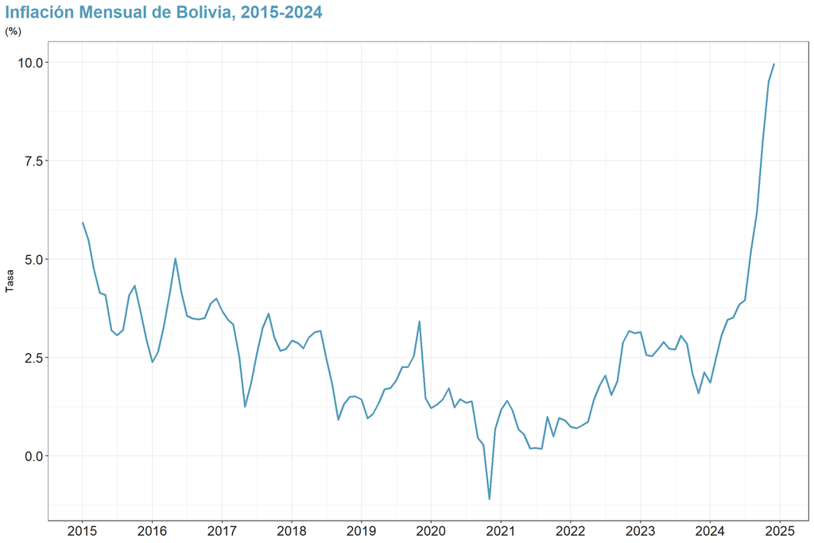

```r
ggplot(Infl, aes(x=Fecha, y=Inflación))+
  geom_line(color="#539CBA", size=1)+
  theme_bw()+
  labs(title="Inflación Mensual de Bolivia, 2015-2024", subtitle = "(%)", x=NULL, y="Tasa")+
  scale_x_date(date_breaks = "year", date_labels = "%Y")+
  theme(
    plot.title = element_text(face="bold", color = "#539CBA", size=18),
    plot.caption.position = "plot",
    plot.title.position = "plot",
    axis.text = element_text(size=14, color="gray12")
  )
```

## 3.2 Evolución de la Distribución de la Inflación Anual

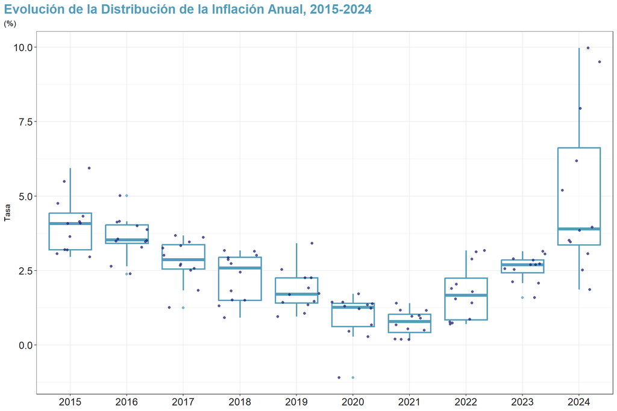

```r
Infl %>%
  mutate(Año_1=as.character(year(Fecha))) %>%
ggplot(aes(x=Año_1, y=Inflación, group=Año_1))+
  geom_boxplot(color="#539CBA", alpha=.7,size=1, show.legend = F)+
  geom_jitter(stat="identity",color="midnightblue", alpha=.7,size=1.5)+
  theme_bw()+
    labs(title="Evolución de la Distribución de la Inflación Anual, 2015-2024", subtitle = "(%)", x=NULL, y="Tasa")+
  theme(
    plot.title = element_text(face="bold", color = "#539CBA", size=18),
    plot.caption.position = "plot",
    plot.title.position = "plot",
    axis.text= element_text( color="gray12",size=14),
  )
```

## 3.3 Inflación Promedio Anual

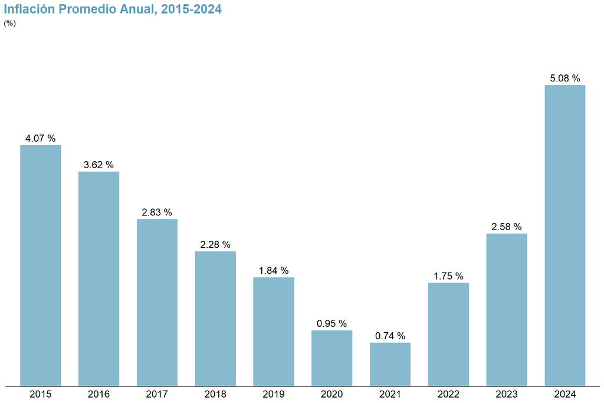

```r
Infl %>%
  mutate(Años_1=as.character(year(Fecha))) %>%
  group_by(Años_1) %>%
  summarise(Inf_Pro=mean(Inflación)) %>%
  ggplot(aes(x=Años_1, y=Inf_Pro))+
  geom_bar(stat = "identity", fill="#539CBA", alpha=.7, width = .7)+
  theme_classic()+
  geom_text(aes(label=paste(round(Inf_Pro,2),"%")), vjust=-.5, hjust="center",size=14, size.unit = "pt")+
  labs(title="Inflación Promedio Anual, 2015-2024", subtitle = "(%)",x=NULL)+
  scale_y_continuous(limits = c(0, 6), expand = c(0, 0))+
  theme(
    plot.title = element_text(face="bold", color = "#539CBA", size=18),
    plot.caption.position = "plot",
    plot.title.position = "plot",
    axis.line.y = element_blank(),
    axis.ticks = element_blank(),
    axis.text.y = element_blank(),
    axis.title.y = element_blank(),
    axis.text.x = element_text(color="black", size=14)
  )
```

# 4 Conversión a Series de Tiempo y Analísis

```r
Infl_ts <- Infl %>%
  select(-c(Años,MES)) %>%
  mutate(Fecha=yearmonth(Fecha)) %>% #Variable tiempo
  as_tsibble(
    index = Fecha#Index
  )
head(Infl_ts,7)
```

```
## # A tsibble: 7 x 2 [1M]
##   Inflación     Fecha
##       <dbl>     <mth>
## 1      5.94 2015 ene.
## 2      5.49 2015 feb.
## 3      4.75 2015 mar.
## 4      4.14 2015 abr.
## 5      4.08 2015 may.
## 6      3.19 2015 jun.
## 7      3.06 2015 jul.
```

## 4.1 Análisis de Estacionalidad

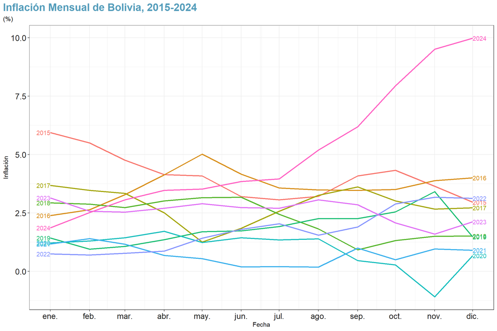

```r
Infl_ts %>%
  gg_season(Inflación, labels = "both", size=1)+
  theme_bw()+
  labs(title="Inflación Mensual de Bolivia, 2015-2024", subtitle = "(%)")+
  coord_cartesian(expand = TRUE)+
  theme(
    plot.title = element_text(face="bold", color = "#539CBA", size=18),
    plot.caption.position = "plot",
    plot.title.position = "plot",
    axis.text= element_text( color="gray12",size=14)
  )
```

## 4.2 Gráfico de subseries estacionales

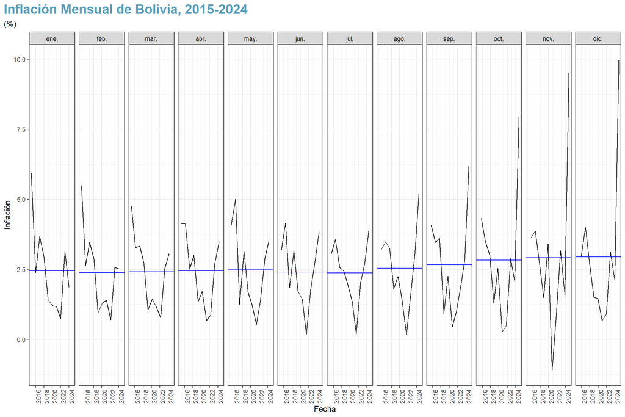

```r
Infl_ts %>%
  gg_subseries(Inflación)+#La media por Mes
  theme_bw()+
  labs(title="Inflación Mensual de Bolivia, 2015-2024", subtitle = "(%)")+
  theme(
    plot.title = element_text(face="bold", color = "#539CBA", size=18),
    axis.text.x = element_text(angle = 90),
    plot.caption.position = "plot",
    plot.title.position = "plot"
  )
```

De acuerdo al análisis, no existe un efecto estacional marcado en la serie. Pero por rutina se procederá a desestacionalizar para eliminar algunos picos.

## 4.3 Desestacionalización

Para la desestacionalización se empleará la técnica creada por la Oficina del Censo de USA X-13ARIMA-SEATS.

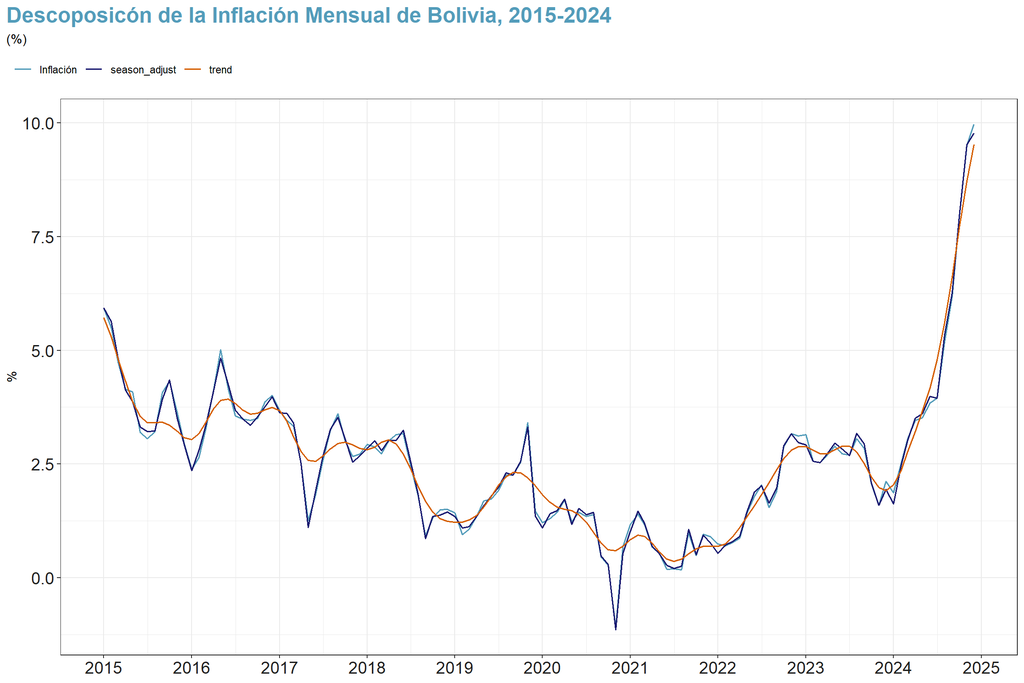

```r
Infl_ts<- Infl_ts %>%
  model(x11 = X_13ARIMA_SEATS(Inflación ~ x11())) %>%
  components() %>%select(-.model)


Infl_ts %>%
  ggplot(aes(x = as_date(Fecha))) +
  geom_line(aes(y = Inflación, colour = "Inflación"), size=0.7) +
  geom_line(aes(y = season_adjust,colour = "season_adjust"), size=0.7) +
  geom_line(aes(y = trend, colour = "trend"), size=0.7) +
  scale_x_date(date_breaks = "year", date_labels = "%Y")+
  scale_colour_manual(
    values = c("#539CBA", "midnightblue", "#D55E00"),
    breaks = c("Inflación", "season_adjust", "trend"))+
  theme_bw()+
  labs(title="Descoposicón de la Inflación Mensual de Bolivia, 2015-2024", subtitle = "(%)", x=NULL, y="%")+
  theme(
    plot.title = element_text(face="bold", color = "#539CBA", size=18),
    legend.position='top',
    legend.justification='left',
    legend.direction='horizontal',
    legend.title = element_blank(),
    plot.caption.position = "plot",
    plot.title.position = "plot",
    legend.location = "plot",
    axis.text= element_text( color="gray12",size=14)
  )
```

# 5 Detección del Orden de Integración (d)

## 5.1 Método Informal

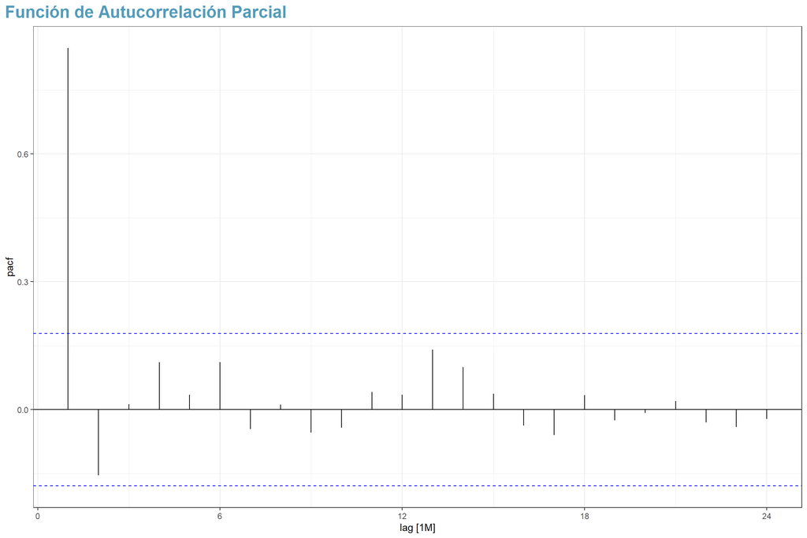

```r
Infl_ts %>%
  PACF(season_adjust, lag_max = 24) %>%
  autoplot()+
  theme_bw()+
  labs(title = "Función de Autucorrelación Parcial")+
  theme(
    plot.title = element_text(face="bold", color = "#539CBA",size=18),
    legend.position='top',
    legend.justification='left',
    legend.direction='horizontal',
    legend.title = element_blank(),
    plot.caption.position = "plot",
    plot.title.position = "plot"
  )
```

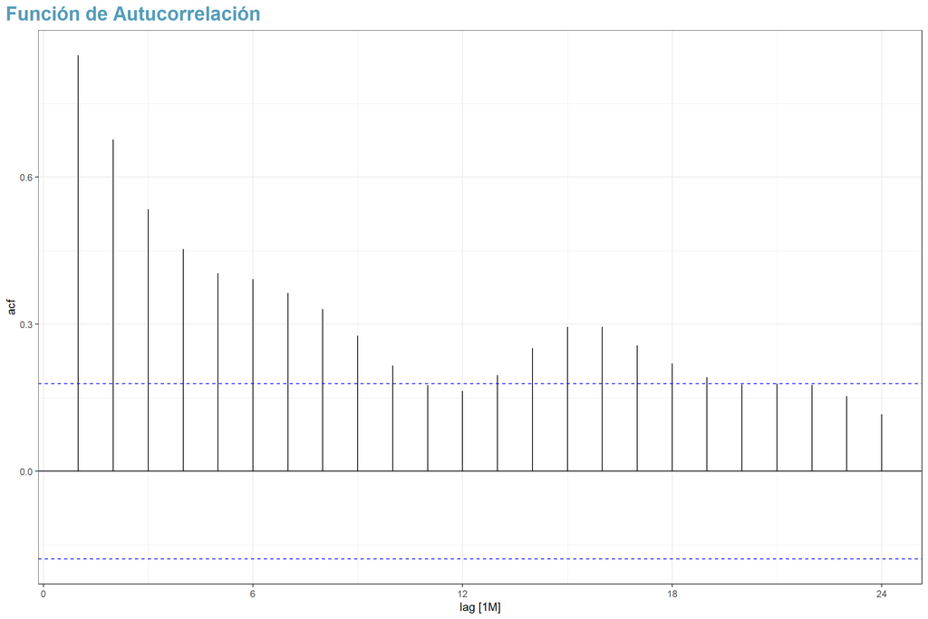

```r
Infl_ts %>%
  ACF(season_adjust, lag_max = 24) %>%
  autoplot()+
  theme_bw()+
  labs(title = "Función de Autucorrelación")+
  theme(
    plot.title = element_text(face="bold", color = "#539CBA", size=18),
    legend.position='top',
    legend.justification='left',
    legend.direction='horizontal',
    legend.title = element_blank(),
    plot.caption.position = "plot",
    plot.title.position = "plot",
  )
```

## 5.2 Método Formal

1. Prueba de Dickey Fuller Aumentada

Ho: La serie tiene raíz unitaria.

```r
#ADF
Infl_ts %>%
  features(season_adjust, adf.test)
```

```
## Augmented Dickey-Fuller Test
## alternative: stationary
##
## Type 1: no drift no trend
##      lag    ADF p.value
## [1,]   0 0.5370   0.797
## [2,]   1 0.0154   0.647
## [3,]   2 0.2017   0.701
## [4,]   3 0.6460   0.828
## [5,]   4 0.7311   0.852
## Type 2: with drift no trend
##      lag     ADF p.value
## [1,]   0  0.0430   0.958
## [2,]   1 -0.8820   0.738
## [3,]   2 -0.7574   0.782
## [4,]   3 -0.0259   0.953
## [5,]   4  0.1145   0.964
## Type 3: with drift and trend
##      lag    ADF p.value
## [1,]   0  0.530   0.990
## [2,]   1 -0.310   0.989
## [3,]   2 -0.123   0.990
## [4,]   3  0.863   0.990
## [5,]   4  1.206   0.990
## ----
## Note: in fact, p.value = 0.01 means p.value <= 0.01
```

```
## # A tibble: 1 × 3
##   type1         type2         type3
##   <list>        <list>        <list>
## 1 <dbl [5 × 3]> <dbl [5 × 3]> <dbl [5 × 3]>
```

2. Prueba de Philip

Ho: La serie no es estacionaria o tiene raíz unitaria.

```r
#P-P
Infl_ts %>%
  features(season_adjust, pp.test)
```

```
## Phillips-Perron Unit Root Test
## alternative: stationary
##
## Type 1: no drift no trend
##  lag Z_rho p.value
##    4 0.446   0.788
## -----
##  Type 2: with drift no trend
##  lag Z_rho p.value
##    4 -2.56   0.702
## -----
##  Type 3: with drift and trend
##  lag Z_rho p.value
##    4  1.71    0.99
## ---------------
## Note: p-value = 0.01 means p.value <= 0.01
```

```
## # A tibble: 3 × 3
##     lag  Z_rho p.value
## * <dbl>  <dbl>   <dbl>
## 1     4  0.446   0.788
## 2     4 -2.56    0.702
## 3     4  1.71    0.99
```

## 5.3 Diferenciación

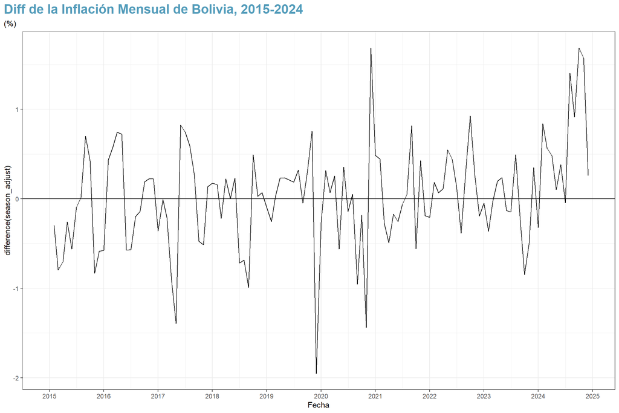

```r
#Diferenciar
Infl_ts %>%
  ggplot(aes(x=Fecha, y=difference(season_adjust)))+
  geom_line()+
  theme_bw()+
  labs(title="Diff de la Inflación Mensual de Bolivia, 2015-2024", subtitle = "(%)")+
  geom_hline(yintercept = 0, size=.5)+
  scale_x_yearmonth(date_breaks = "1 year", date_labels = "%Y")+
  theme(
    plot.title = element_text(face="bold", color = "#539CBA", size=18),
    plot.caption.position = "plot",
    plot.title.position = "plot"
  )
```

De acuerdo con las pruebas formales e informales, se evidencia que la serie es integrada de orden (1).

# 6 Identificar los Procesos AR(p) y MA(q)

De la función de autocorrelación parcial se obtiene el orden del modelo AR(p) y de la función de autocorrelación, el orden del modelo MA(q).

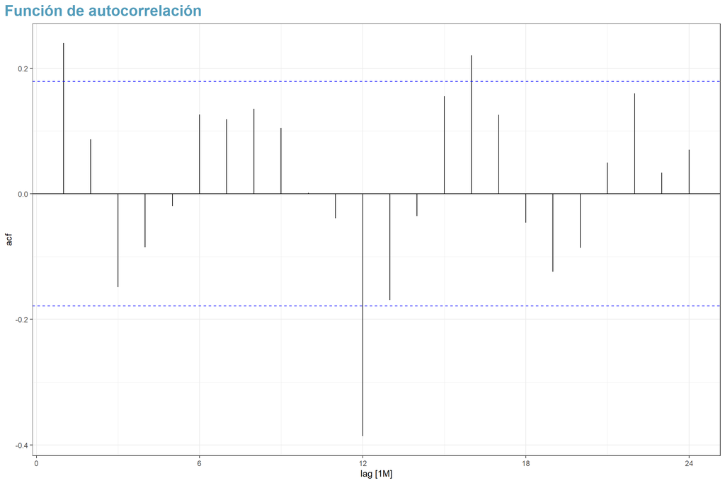

```r
Infl_ts %>%
  ACF(difference(season_adjust), lag_max = 24) %>%
  autoplot()+
  theme_bw()+
  labs(title="Función de autocorrelación")+
  theme(
    plot.title = element_text(face="bold", color = "#539CBA", size=18),
    plot.caption.position = "plot",
    plot.title.position = "plot"
  )
```

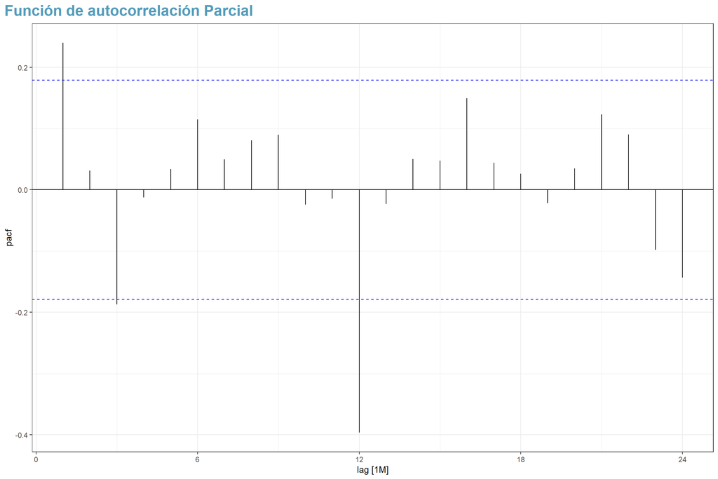

```r
Infl_ts %>%
  PACF(difference(season_adjust), lag_max = 24) %>%
  autoplot()+
  theme_bw()+
  labs(title="Función de autocorrelación Parcial")+
  theme(
    plot.title = element_text(face="bold", color = "#539CBA", size=18),
    plot.caption.position = "plot",
    plot.title.position = "plot"
  )
```

De acuerdo a las gráficas, sugiere un modelo ARIMA(3,1,1), aunque da la percepción de ser un modelo estacional dado que el pico en el rezago 12 es significativo, es decir, ARIMA(3,1,1)S(1,0,1)[12].

# 7 Estimar el Modelo ARIMA(pdq)

Ahora se estimarán los modelos candidatos posibles.

```r
#Modelos
Model <- Infl_ts %>%
  model(
    arima011 = fable::ARIMA(season_adjust~ pdq(0,1,1)),
    arima310 = fable::ARIMA(season_adjust ~ pdq(3,1,0)),
    arima311 = fable::ARIMA(season_adjust~ pdq(3,1,1)),
    #Estacionales
    arima_311S = fable::ARIMA(season_adjust~ pdq(3,1,1)+PDQ(1,0,1)),
    arima_011S = fable::ARIMA(season_adjust~ pdq(0,1,1)+PDQ(0,0,1)),
    arima_310S = fable::ARIMA(season_adjust~ pdq(3,1,0)+PDQ(1,0,0)),
  )
```

Para la elección del mejor modelo se hará uso de los criterios de información: Elegir el modelo cuyos estadísticos o criterios de información se minimicen y, para el caso de la razón de verosimilitud (LL), elegir el modelo cuyo estadístico o criterio de razón de verosimilitud se maximice (mayor valor).

```r
#Encontrar el mejor modelo
glance(Model) %>% arrange(AICc) %>% select(.model:BIC)
```

```
## # A tibble: 5 × 6
##   .model     sigma2 log_lik   AIC  AICc   BIC
##   <chr>       <dbl>   <dbl> <dbl> <dbl> <dbl>
## 1 arima310    0.248   -86.1  182.  183.  196.
## 2 arima011    0.257   -88.9  184.  184.  192.
## 3 arima_011S  0.257   -88.9  184.  184.  192.
## 4 arima_310S  0.259   -87.9  186.  186.  200.
## 5 arima311    0.260   -87.6  187.  188.  204.
```

De acuerdo con los resultados, el mejor modelo es el ARIMA(3,1,0), dado que más de un criterio los respalda.

## 7.1 Gráfico de los Residuos

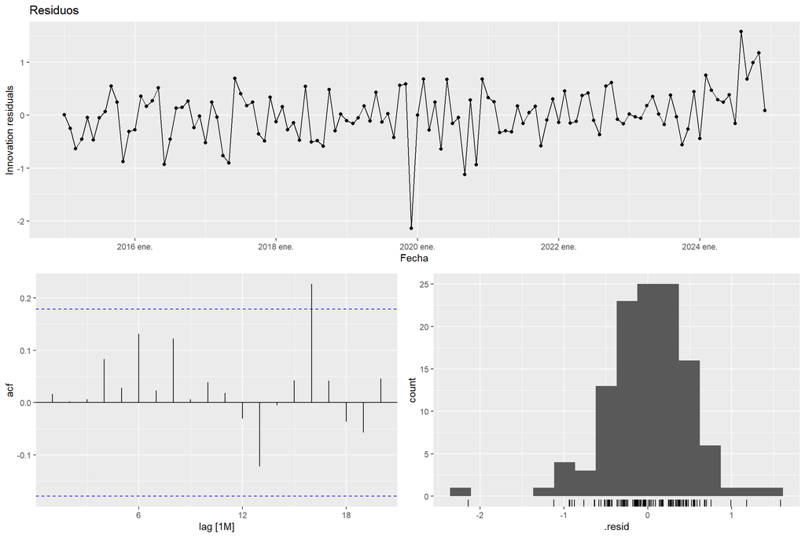

```r
Model %>%
  select(arima310) %>%
  gg_tsresiduals()+
  labs(title="Residuos")
```

## 7.2 Test de Ruido Blanco (ljung_box)

Ho: La serie es Ruido blanco.

```r
augment(Model) %>%
  filter(.model=="arima310") %>%
  features(.innov, ljung_box, lag = 36, dof = 6)
```

```
## # A tibble: 1 × 3
##   .model   lb_stat lb_pvalue
##   <chr>      <dbl>     <dbl>
## 1 arima310    37.2     0.170
```

Aunque no se rechaza la H0, existe presencia de valores atípicos.

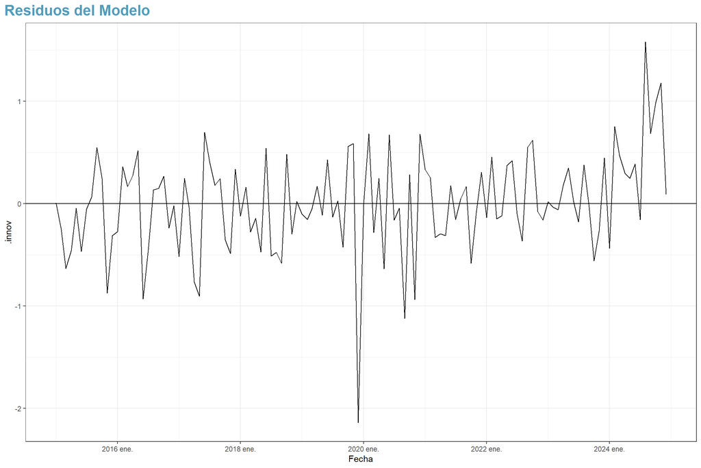

```r
resid <- augment(Model)
#Gráficos de los residuos
resid %>%
  filter(.model=="arima310") %>%
  ggplot(aes(x=Fecha,y=.innov))+
  geom_line()+
  geom_hline(yintercept = 0)+
  labs(title = "Residuos del Modelo")+
  theme_bw()+
  theme(
    plot.title = element_text(face="bold", color = "#539CBA", size=18),
    plot.caption.position = "plot",
    plot.title.position = "plot"
  )
```

## 7.3 Detección de Oulier

La técnica empleada para detectar outlier será el diagrama de caja.

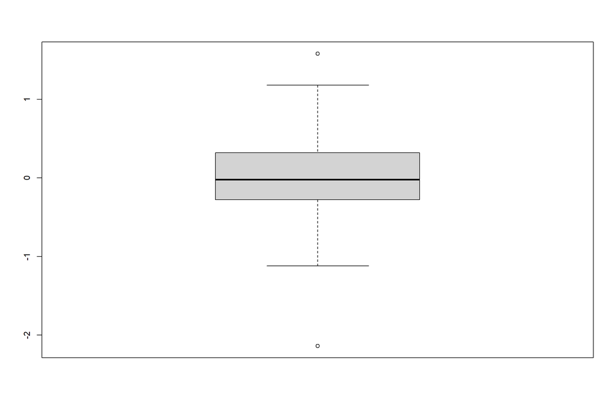

```r
#Detectando oulier en resid
data <- augment(Model)%>%
  filter(.model=="arima310")
Oulier <- boxplot(data$.innov)$out
```

```r
Oulier
```

```
## [1] -2.138903  1.580320
```

```r
#Ubicar los outliers
data %>%
  filter(.innov%in%Oulier)
```

```
## # A tsibble: 2 x 6 [1M]
## # Key:       .model [1]
##   .model       Fecha season_adjust .fitted .resid .innov
##   <chr>        <mth>         <dbl>   <dbl>  <dbl>  <dbl>
## 1 arima310 2019 dic.          1.36    3.50  -2.14  -2.14
## 2 arima310 2024 ago.          5.35    3.77   1.58   1.58
```

Los valores atípicos u outliers se encuentran en la fecha **dic/2019** y **Agos/2024**

## 7.4 Creación de dummys

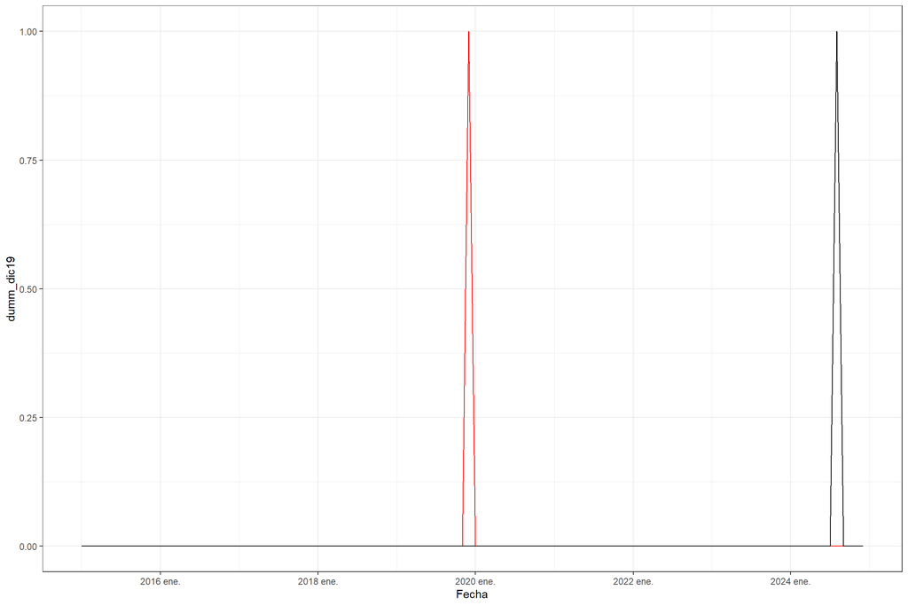

```r
#Agregamos dummies a la data ts
Infl_ts <- Infl_ts %>%
  mutate(dumm_dic19=ifelse(as.character(Fecha)=="2019 dic.",1,0),
         dumm_ago24=ifelse(as.character(Fecha)=="2024 ago.", 1,0))

ggplot(Infl_ts,aes(x=Fecha))+
  geom_line(aes(y=dumm_dic19), color="red")+
  geom_line(aes(y=dumm_ago24))+
  theme_bw()
```

# 8 Modelo Corregido

```r
#Modelo Corregido
Model_cor <- Infl_ts %>%
  model(
    arima011 = fable::ARIMA(season_adjust~ pdq(0,1,1)+dumm_dic19+dumm_ago24),
    arima310 = fable::ARIMA(season_adjust ~ pdq(3,1,0)+dumm_dic19+dumm_ago24),
    arima311 = fable::ARIMA(season_adjust~ pdq(3,1,1)+dumm_dic19+dumm_ago24),
    auto = fable::ARIMA(season_adjust)
  )

#Encontrar el mejor modelo
glance(Model_cor) %>% arrange(AICc) %>% select(.model:BIC)
```

```
## # A tibble: 4 × 6
##   .model   sigma2 log_lik   AIC  AICc   BIC
##   <chr>     <dbl>   <dbl> <dbl> <dbl> <dbl>
## 1 arima311  0.218   -78.0  174.  176.  199.
## 2 arima310  0.239   -82.5  179.  180.  198.
## 3 auto      0.243   -86.1  180.  181.  191.
## 4 arima011  0.252   -86.3  183.  183.  197.
```

El mejor modelo es el ARIMA(3,1,1)

## 8.1 Gráfico de Residuos

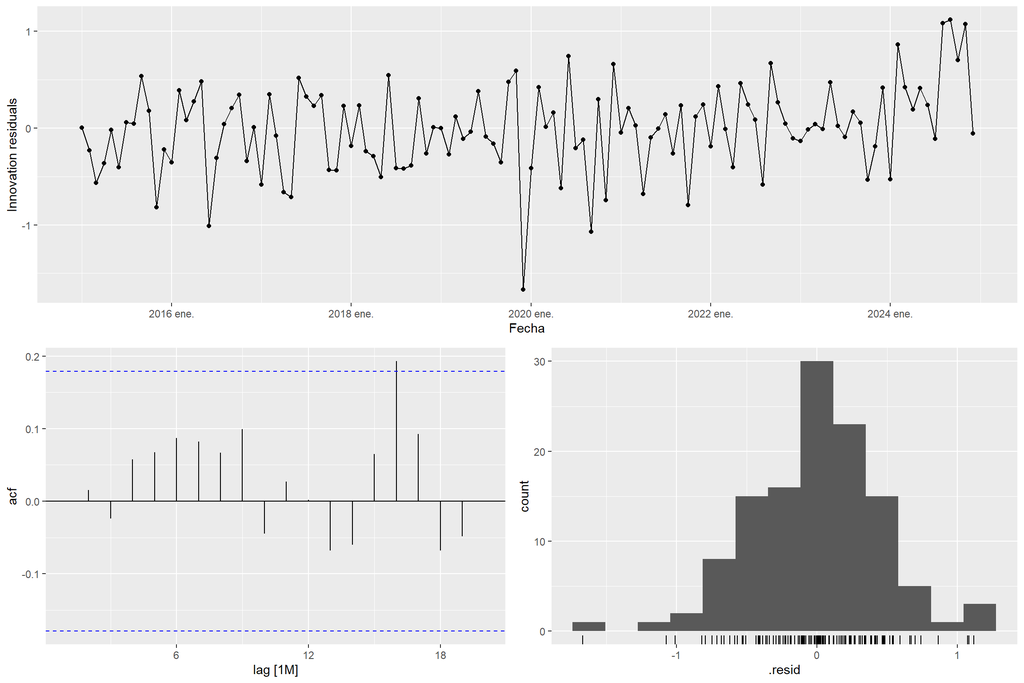

```r
Model_cor %>%
  select(arima311) %>%
  gg_tsresiduals()
```

## 8.2 Test de Ruido Blanco

```r
augment(Model_cor) %>%
  filter(.model=="arima311") %>%
  features(.innov, ljung_box, lag = 36, dof = 6)
```

```
## # A tibble: 1 × 3
##   .model   lb_stat lb_pvalue
##   <chr>      <dbl>     <dbl>
## 1 arima311    26.4     0.655
```

# 9 Comparación de los modelos (Corregido y el Simple)

```r
Model_Sim <- glance(Model) %>% arrange(AICc) %>% select(.model:BIC) %>%
  filter(.model=="arima310")

Model_Core <- glance(Model_cor) %>% arrange(AICc) %>% select(.model:BIC) %>%
              filter(.model=="arima311")
#El mejor modelo es el Arima corregido
#Pruebas ex
bind_rows(Model_Sim, Model_Core)
```

```
## # A tibble: 2 × 6
##   .model   sigma2 log_lik   AIC  AICc   BIC
##   <chr>     <dbl>   <dbl> <dbl> <dbl> <dbl>
## 1 arima310  0.248   -86.1  182.  183.  196.
## 2 arima311  0.218   -78.0  174.  176.  199.
```

De acuerdo al AIC y log_lik, el modelo final es el ARIMA(3,1,1).

# 10 Pronóstico

```r
#Creación de una data para el Pronostico
Data <- new_data(Infl_ts, 12) |>
  mutate(
    dumm_ago24 = 0,#Las variables exogenas
    dumm_dic19= 0,
    )

#Pronostico (Data)
forecast(Model_cor,Data) |>
  filter(.model=="arima311") %>%
  hilo()
```

```
## # A tsibble: 12 x 8 [1M]
## # Key:       .model [1]
##    .model       Fecha
##    <chr>        <mth>
##  1 arima311 2025 ene.
##  2 arima311 2025 feb.
##  3 arima311 2025 mar.
##  4 arima311 2025 abr.
##  5 arima311 2025 may.
##  6 arima311 2025 jun.
##  7 arima311 2025 jul.
##  8 arima311 2025 ago.
##  9 arima311 2025 sep.
## 10 arima311 2025 oct.
## 11 arima311 2025 nov.
## 12 arima311 2025 dic.
## # ℹ 6 more variables: season_adjust <dist>, .mean <dbl>, dumm_ago24 <dbl>,
## #   dumm_dic19 <dbl>, `80%` <hilo>, `95%` <hilo>
```

## 10.1 Gráfico de Pronóstico de la Inflación

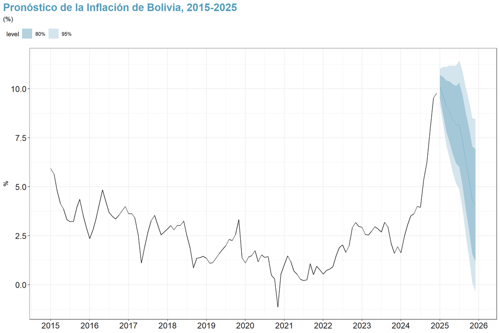

```r
#Gráfico
forecast(Model_cor,Data) %>%
  filter(.model=="arima311") %>%
  autoplot(Infl_ts, color=alpha("#539CBA",.5))+
  theme_bw()+
  scale_x_yearmonth(date_breaks = "1 year", date_labels = "%Y")+
  labs(title="Pronóstico de la Inflación de Bolivia, 2015-2025", subtitle = "(%)",
       x=NULL, y="%")+
  theme(
    plot.title = element_text(face="bold", color = "#539CBA", size=18),
    legend.position='top',
    legend.justification='left',
    legend.direction='horizontal',
    plot.caption.position = "plot",
    plot.title.position = "plot",
    legend.location = "plot",
    axis.text= element_text( color="gray12",size=14)
  )
```

## 10.2 Inflación Promedio Anual

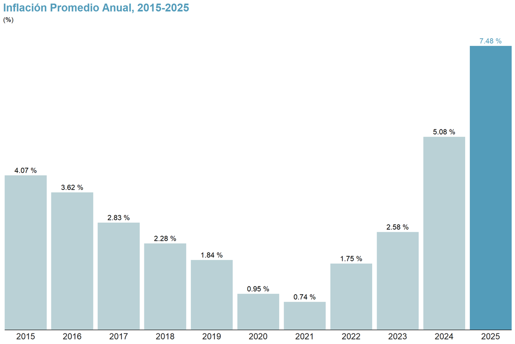

```r
#Pronostico de la Inflación anual promedio
Data2 <- bind_rows(Infl_ts,
          forecast(Model_cor,Data) %>%
            filter(.model=="arima311") %>%
            hilo())
Data2 %>%
  mutate(Años=as.character(year(Fecha))) %>%
  group_by(Años) %>%
  as_tibble() %>%
  select(-Fecha) %>%
  summarise(Infl=mean(Inflación, na.rm = TRUE), Pron=mean(.mean, na.rm=TRUE)) %>%
  mutate(is_2025=ifelse(Años==2025, TRUE, FALSE)) %>%
  ggplot(aes(x=Años,y=Infl, fill=is_2025))+
  geom_bar(stat = "identity", show.legend = F)+
  geom_bar(aes(y=Pron), stat = "identity", show.legend = F)+
  scale_fill_manual(breaks = c(FALSE, TRUE), values = c("#BAD1D6","#539CBA"))+
  coord_cartesian(expand = FALSE,
                  ylim = c(0,8))+
  theme_classic()+
  theme(
    plot.title = element_text(face="bold", color = "#539CBA", size=18),
    axis.line.y = element_blank(),
    axis.ticks = element_blank(),
    axis.text.x = element_text(size=14, color="gray12"),
    axis.text.y = element_blank(),
    plot.caption.position = "plot",
    plot.title.position = "plot"
  )+
  geom_text(aes(y=Pron,label=ifelse(is_2025,paste(round(Pron,2),"%"),NA)), vjust=-.5, hjust="center", color="#539CBA",size=12, size.unit = "pt")+
  geom_text(aes(label=paste(round(Infl,2),"%")), vjust=-.5, hjust="center", size=12, size.unit = "pt")+
  labs(title="Inflación Promedio Anual, 2015-2025", subtitle = "(%)",x=NULL,y=NULL)
```

# 11 Conclusión

De acuerdo a los datos y la aplicación de la metodología de Box-Jenkins (1976):

- El modelo ARIMA empleado es el ARIMA(3,1,1) corregido por la influencia de valores atípicos.
- La inflación promedio pronosticada para el año 2025 alcanzará el 7.48%, 2.4 pp por encima del promedio registrado en 2024.
- Además, de acuerdo con los datos, la inflación en el último semestre del año 2024 presentó una dispersión marcada, terminando el año con una inflación de 9.97%